# TP3

Remarque préliminaire : on adoptera dans ce TP la paramétrisation de la loi gamma (shape, scale).

#PARTIE 1

##QUESTION 1

On a :
$$y_i \sim P(\theta) : p(y_i = k_i) = e^{-\theta}\dfrac{\theta^{k_i}}{k_i!}\\
P(y|\theta) = \prod_{i=1}^n e^{-\theta}\dfrac{\theta^{k_i}}{k_i!}$$

##QUESTION 2

On a : $p(\theta) \propto \dfrac{1}{\theta}$
$$p(\theta|y) = \dfrac{p(y|\theta) p(\theta)}{p(y)} \propto p(y|\theta)p(\theta)\\
\propto e^{-n\theta}\left( \prod_{i=1}^n \dfrac{\theta^{k_i}}{k_i!} \right) \times \dfrac{1}{\theta}\\
\propto \dfrac{e^{-n\theta}}{\theta} \prod_{i=1}^n \dfrac{\theta^{k_i}}{k_i!}\\
\propto \dfrac{e^{-n\theta}\theta^{K - 1}}{\prod_{i=1}^n k_i !}$$
où $K = (\sum_{i=1}^n k_i)$.

$$\propto \dfrac{ e^{- \frac{\theta}{1/n}} \theta^{K - 1} }{\prod_{i=1}^n k_i!}$$

Le dénominateur est une constante :
$$\propto e^{- \frac{\theta}{1/n}} \theta^{K - 1} \propto f(\theta, K, \frac{1}{n})$$
où $f$ est la fonction de densité d’une loi gamma de paramètres : $\Gamma(K, \frac{1}{n})$.

La loi à postériori du paramètre $\theta$ est donc une loi gamma de paramètres $K, \frac{1}{n}$. Son espérance est donc : $\mathbb{E}(\theta|y) = K \times \dfrac{1}{n}$

##QUESTION 3

Le principe de l’algorithme de Metropolis-Hasting est de, à partir de la loi $\Pi(\theta)$, et d’une loi instrumentale choisie, simuler une chaine de Markov convergeant vers $\Pi(\theta)$, sa loi stationnaire. Cela permet d’échantilloner des lois dont on ne peux pas calculer la constante de normalisation, ce qui est notre cas ici.

On choisit une loi instrumentale exponentielle de paramètre $\lambda$.

Le calcul de $r$ ne pose mathématiquement pas de problème, mais il fait intervenir de nombreux rapport d’exponentielles de très petits nombres, et des puissances très élevées : beaucoup d’erreur d’approximation et de dépacement de capacité causent des problèmes (apparitions de NaN). Pour éviter cela, on calcule le rapport plus intelligemment :

$$r = \dfrac{(\theta^*)^{K-1} \times e^{-n\theta^*} \times \lambda e^{-\lambda \theta_t}}{(\theta_t)^{K-1} \times e^{-n\theta_t} \times \lambda e^{-\lambda \theta^*}}\\
= (\dfrac{\theta^*}{\theta_t})^{K - 1} \times e^{(n - \lambda)(\theta_t - \theta^*)}$$
Si $\theta^*$ de même signe que $\theta_t$ :
$$(\dfrac{\theta^*}{\theta_t})^{K - 1} = \exp( (K - 1) \ln(\dfrac{\theta^*}{\theta_t}))$$

Sinon :

$$(\dfrac{\theta^*}{\theta_t})^{K - 1} = (-1)^{K - 1} \exp( (K - 1) \ln(-\dfrac{\theta^*}{\theta_t}))$$
On obtient donc comme formule du calcul de r final :
$$r = (\pm 1) ^{K - 1} \exp\left\{(n - \lambda)(\theta_t - \theta^*) + (K - 1) \ln(\pm\dfrac{\theta^*}{\theta_t})\right\}$$
Cette formule a pour avantage de n’avoir que une seule exponentielle à calculer : l’exponentielle en elle-même ne peux pas produire de NaN. A l’intérieur, on a la somme d’un terme calculable par ordinateur, et d’un logarithme, qui dans le pire des cas vaut -Inf (en supposant $\theta_t, \theta^*$ toujours strictements positifs) : $\exp(-Inf) = 0$.

Finalement, on choisit $\lambda = \dfrac{n}{K}$, pour que la moyenne de la loi instrumentale corresponde à celle de la loi stationnaire : on propose ainsi des valeurs qui ont plus de chances d’être acceptées.

```r
tirage_loi_instrumentale <- function(){
    return(rexp(1, rate = (n / K)))
}
```

```r
calcul_r <- function(theta_t, theta_etoile){
    if (theta_t == 0) {
        theta_t = 0.000001
    }
    if (theta_etoile == 0){
        theta_etoile = 0.0000001
    }


    if (theta_etoile * theta_t > 0){
        #meme signe
        val = exp( (K - 1) * log(theta_etoile / theta_t) + n * (1 - (1/K)) * (theta_t - theta_etoile))
    } else {
        #signes opposés
        val = (-1)**(K-1) * exp( (K - 1) * log(- theta_etoile / theta_t) + n * (1 - (1/K)) * (theta_t - theta_etoile))
    }
    return(val)
}
```

```r
metropolisHasting <- function(nb_iterations){
    #etape 1
    theta_t = K/n #Initialisation de theta_0

    #iterations :
    for (i in 1:nb_iterations) {
        #etape 2
        theta_etoile = tirage_loi_instrumentale()
        #etape 3
        r = calcul_r(theta_t, theta_etoile)
        #etape 4
        if (runif(1) < min(1,r)) {
            theta_t <- theta_etoile
        }
        #Sinon on ne change pas theta_t
    }
    return(theta_t)
}
```

```r
generationMetropolis <- function(n, nb_iter){
    vect = c()
    for (i in 1:n){
        vect = c(vect, metropolisHasting(nb_iter))
    }
    return(vect)
}
```

##Question 4

```r
#Chargement de l'échantillon
echantillon = scan("echantillon.txt")
```

```r
#Calcul des paramètres de la loi Gamma :
K = sum(echantillon)
n = length(echantillon)
```

```r
echantillon_genere = generationMetropolis(200,30000)
```

```r
#moyenne, médialle, quartiles :
summary(echantillon_genere)
```

```
##    Min. 1st Qu.  Median    Mean 3rd Qu.    Max.
##   10.46   10.97   11.11   11.13   11.31   11.81
```

```r
#intervalle de confiance centré à 95% :
quantile(echantillon_genere, c(0.025, 0.975))
```

```
##     2.5%    97.5%
## 10.69434 11.62594
```

##QUESTION 5

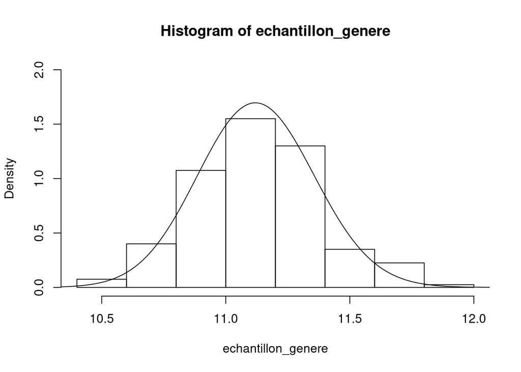

```r
hist(echantillon_genere, freq = FALSE, ylim = c(0,2))
intervalle = (0:2000) / 100
lines(intervalle, dgamma(intervalle, shape = K, scale = 1/n))
```

##QUESTION 6

On a :

$$p(\tilde{y}|t) \propto \int p(\tilde{y}|\theta) p(\theta|y)d\theta \\
\propto \int \dfrac{1}{\tilde{y!}} \theta^\tilde{y}e^{-\theta} \times e^{-n\theta} \theta^{K - 1}d\theta
\propto \dfrac{1}{\tilde{y}!} \int_0^{+ \infty} e^{-(n+1)\theta} \theta^{K+\tilde{y}-1} d\theta \\$$
On remarque que l’intégrale est proportionelle à la fonction de répartition d’une loi gamma de paramètres $K + \tilde{y}, \dfrac{1}{n+1}$ : l’intégrale est donc proportionelle a 1 car étant prise entre 0 et l’infini. On a donc :
$$p(\tilde{y}|t) \propto \dfrac{1}{\tilde{y!}}$$
On simule cette nouvelle variable par l’algorithme de Monte-Carlo : on simule $p(\theta | y)$, puis $p(\tilde{y}|\theta)$ :

```r
simulation_y_tilde <- function(theta){
    return(rpois(1, theta))
}
```

```r
Monte_carlo <- function(n){
    vect = c()
    for (i in 1:n){
        theta = metropolisHasting(20000)
        y_tilde = simulation_y_tilde(theta)
        vect = c(vect, y_tilde)
    }
    return(vect)
}
```

```r
simu = Monte_carlo(n)
summary(simu)
```

```
##    Min. 1st Qu.  Median    Mean 3rd Qu.    Max.
##    2.00    8.00   10.00   10.54   12.00   19.00
```

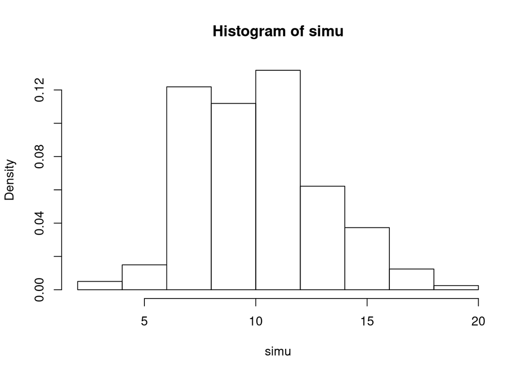

```r
histSim <- hist(simu, freq = FALSE)
```

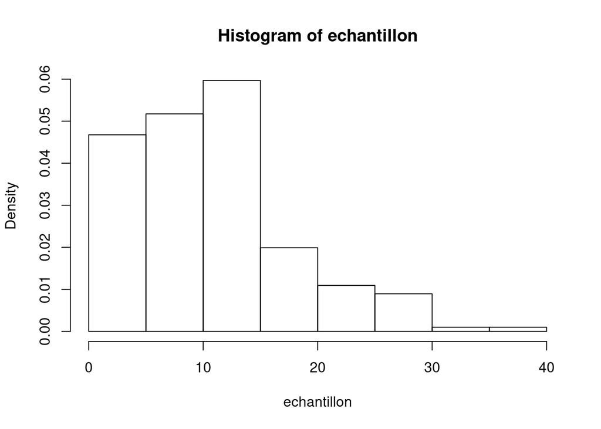

```r
histDonnees <- hist(echantillon, freq = FALSE)
```

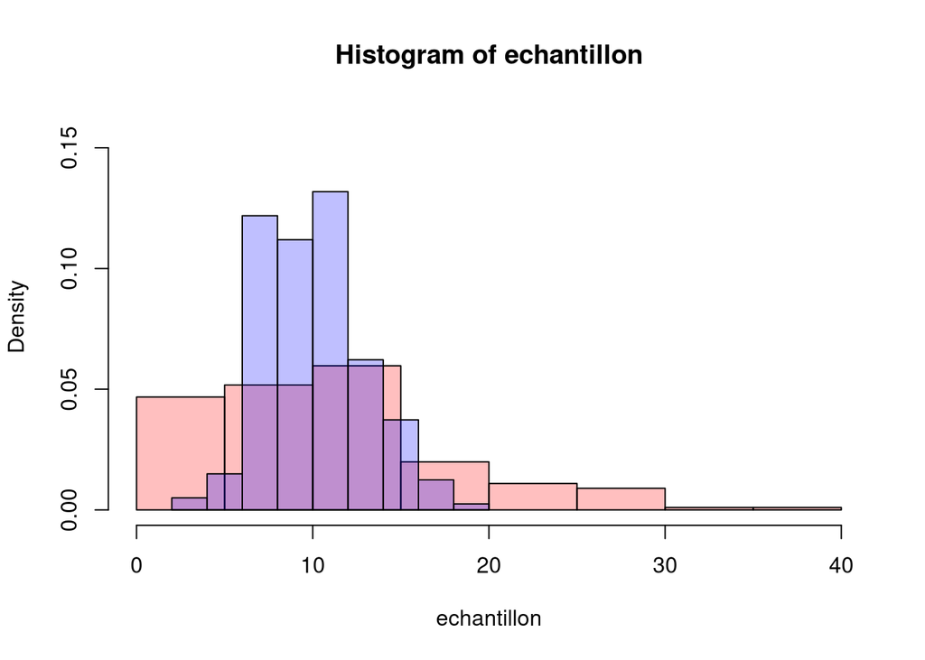

```r
#en rouge, les donnees
plot(histDonnees, col = rgb(1,0,0,1/4), ylim = c(0,0.16), freq = FALSE)
#en bleu, les donnes simulees
plot(histSim, col = rgb(0,0,1,1/4), freq = FALSE, add = T)
```

On voit que le modèle n’est pas très adapté : même s’il estime bien $\theta$ (les moyennes correspondent), les valeurs simulées ne sont pas aussi écartées que dans la réalité : les valeurs sont trop centrées sur la moyenne.

#PARTIE 2

##Question 1

$$p(y|z, \theta) = \frac{p(y,z|\theta)}{p(z|\theta)}\\
p(y|z, \theta) \propto \prod_{i,k} \frac{(\theta _k)^{y_i}exp(-\theta _k)}{y_i !} \\
\propto \prod_k exp(-\theta _k) \prod_i \dfrac{(\theta _k)^{y_i}}{y_i!}$$

##Question 2

$$p(z, \theta|y) = \frac{p(y|z,\theta)p(z,\theta)}{p(y)} \\
\propto p(y|z,\theta)p(z, \theta) \\
\propto \left( \prod_k exp(-\theta _k) \prod_i \dfrac{(\theta _k)^{y_i}}{y_i!} \right) p(z)p(\theta) \\
\propto \left( \prod_k exp(-\theta _k) \prod_i \dfrac{(\theta _k)^{y_i}}{y_i!} \right) p(z) \prod_k p(\theta_k)$$
Or, $p(\theta _k) \propto \frac{1}{\theta _k}$ et $p(z) \propto 1$. Donc :
$$p(z, \theta | y) \propto \left( \prod_k exp(-\theta _k) \prod_i \dfrac{(\theta _k)^{y_i}}{y_i!} \right) \prod_{k} \frac{1}{\theta _k} \\
\propto \prod_k \dfrac{exp(-\theta _k)}{\theta_k} \prod_i \dfrac{(\theta _k)^{y_i}}{y_i!}$$

##Question 3

$$p(z_i = k|y, \theta) = \dfrac{p(z_i | y_i, \theta)}{p(y_i|\theta)} = \dfrac{p(y_i|z_i, \theta)}{\sum_ k p(y_i|z_i=k, \theta)} \propto p(y_i|z_i, \theta)\\
\propto \dfrac{(\theta_{z_i})^{y_i}e^{-\theta_{z_i}}}{y_i!}$$

On reconnait ici une loi de poisson de paramètre $\theta_{z_i}$.

##Question 4

$$p(\theta _k | \theta _{-k}, y, z) = \frac{p(\theta, y, z)}{p(z, y, \theta _{-k})} = \frac{p(z, \theta |y) p(y)}{p(z, y, \theta _{-k})}$$
$$\propto \frac{p(z, \theta | y)}{p(\theta _{-k}, z |y)p(y)}$$
$$\propto \frac{p(z, \theta |y)}{p(\theta _{-k}, z | y)}$$
$$\propto \frac{ \prod \limits_{j} \frac{1}{\theta_j} \prod \limits_{i \in I_j} \frac{(\theta _j)^{y_i} exp(-\theta _j)}{y_i!} }{ \prod \limits_{j \neq k} \frac{1}{\theta_j} \prod \limits_{i \in I_j} \frac{(\theta _j) ^{y_i} exp(-\theta _j)}{y_i!}}$$
$$\propto \frac{1}{\theta _k} \prod_{i \in I_k} \frac{(\theta _k) ^{y_i} e^{-\theta _k}}{y_i!}$$
$$\propto \frac{1}{\theta _k} \prod_{i \in I_k} (\theta _k) ^{y_i} e^{-\theta _k}$$
$$\propto \frac{e^{-n_k \theta _k}}{\theta _k} (\theta _k)^{n_k \bar{y}_k}$$
Enfin :
$$p(\theta _k | \theta _{-k}, y, z) \propto \theta _k^{n_k \bar{y}_k -1} \textrm{exp}(-n_k \theta _k)$$
On reconnait une loi gamma de paramètres $(n_k \bar{y_k}, \frac{1}{n_k})$.

##Question 5

```r
#On simule z à partir de theta.

simulation_z<- function(theta, y, z){
    val = c()
    K = length(theta)
    for (i in 1:length(y)){
        p = ((theta^y[i]) * exp(- theta)) / factorial(y[i])
        val = c(val, sample(1:K, 1, prob = p))
    }
    return(val)
}
```

```r
#On simule des valeurs de theta a partir de z
#z suit une loi gamma: on simule a partir de rgamma

simulation_theta <- function(z, y, theta){
  theta_sim = c()
  K = length(theta)
  for (k in 1:K){
    nk = length(z[z == k]) #Nombre de valeurs de z egales a k
    yk = mean(y[z == k])  #yi ou i tq zi == k, c'est a dire yi avec i dans Ik
    #if (is.na(yk)){
    #  yk = 10
    #}
    theta_sim = c(theta_sim, rgamma(1, shape = nk * yk, scale = 1/nk))
  }
  return(theta_sim)
}
```

```r
initialisation_theta <- function(n){
    theta = 20 * runif(n)
    return(theta)
}
```

#algo de Gibbs

```r
gibbs <-function(y, K) {
  n = length(y)

  theta = initialisation_theta(K)
  z = sample(1:K, n, replace = T)

  for (i in 1:1000){
    theta = simulation_theta(z, y, theta)
    z = simulation_z(theta, y, z)
  }

  return(list(theta = theta, z = z))
}
```

```r
#genere n valeurs via gibbs
gen_gibbs <- function(y, K ,n ){
    val = c()
    for (i in 1:n){
        val = c(val, gibbs(y, K))
    }
    return(val)
}
```

##Question 6 On peut estimer l’espérence de $\theta_k$ sachant $y$ en faisant la moyenne empirique sur un certain nombre de générations de l’algorithme précédent. Les proportions de chaque composante peuvent quant à elles être estimées en regardant les proportions de chaque $z_i$.

```r
estimation_theta <- function(theta){
    return(mean(theta))
}
```

```r
estimation_proportions <- function(z, K){
    prop = c()
    for (i in 1:K){
        prop = c(prop, mean(z[z==i]))
    }
    return(prop)
}
```

##Question 7

```r
loi_melange <- function (p, theta){
  classe_choisie = sample(1:length(theta), 1, prob = p)
  val_melange = rpois(1, theta[classe_choisie])
  return(val_melange)
}



gen_melange <-function(p, theta, n){
   gen= c()
   for (i in 1:n){
     gen = c(gen, loi_melange(p, theta))
   }
   return(gen)
}
```

On aura dans la suite, l’échantillon donné en rouge, et celui simulé en bleu.

K = 4

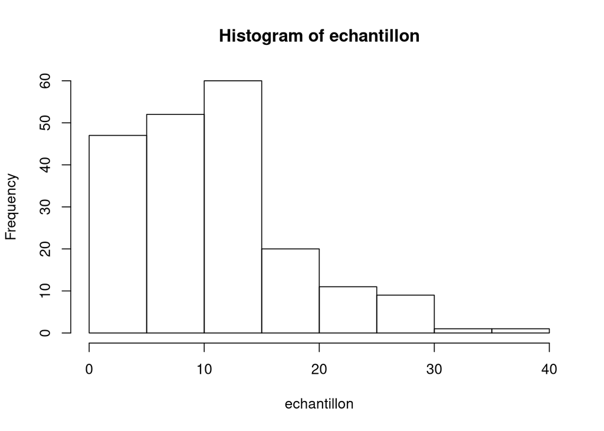

```r
K = 4
K_4 = gibbs(echantillon, K)

theta_moyen = estimation_theta(K_4$theta)
p = estimation_proportions(K_4$z, K)
theta = K_4$theta

hist_ech = hist(echantillon)
```

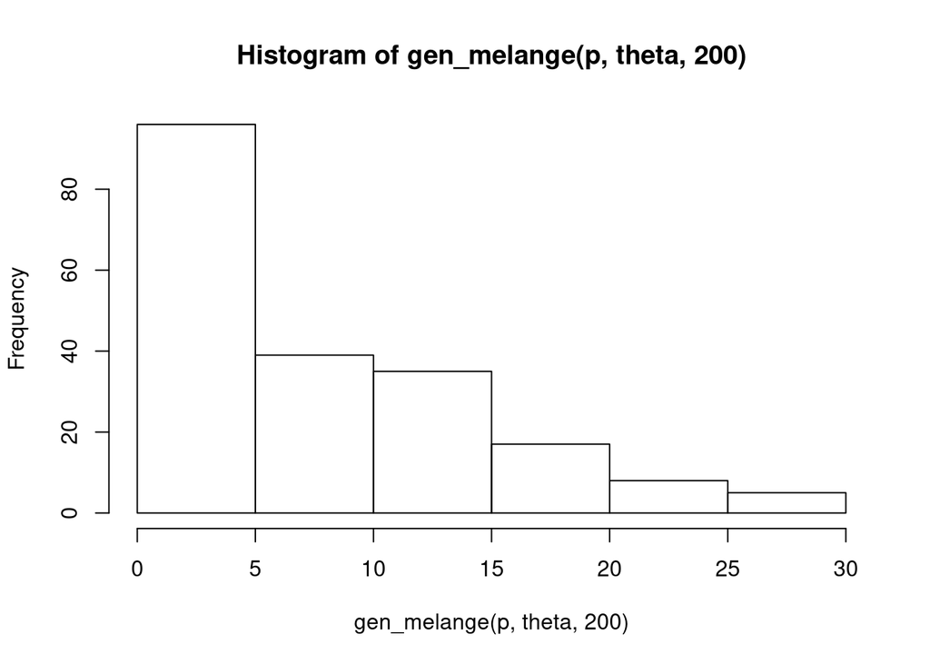

```r
hist_k4 = hist(gen_melange(p, theta, 200))
```

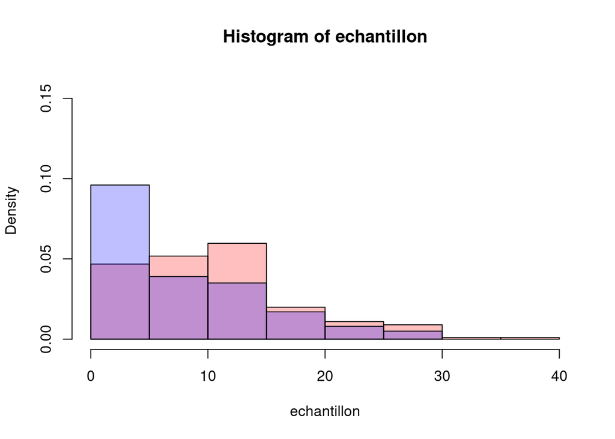

```r
plot(hist_ech, col = rgb(1,0,0,1/4), ylim = c(0,0.16), freq = FALSE)
plot(hist_k4, col = rgb(0,0,1,1/4), freq = FALSE, add = T)
```

K = 5

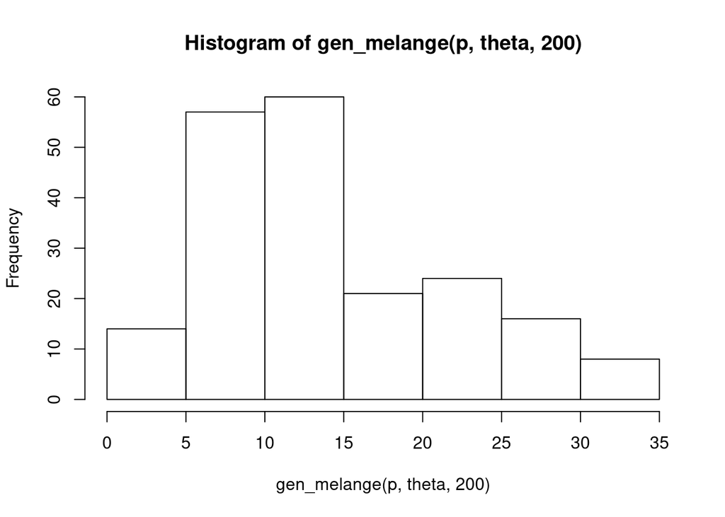

```r
K = 5
K_4 = gibbs(echantillon, K)

theta_moyen = estimation_theta(K_4$theta)
p = estimation_proportions(K_4$z, K)
theta = K_4$theta

hist_k4 = hist(gen_melange(p, theta, 200))
```

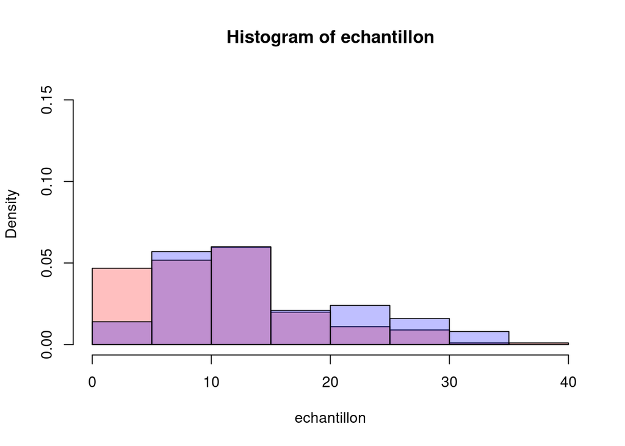

```r
plot(hist_ech, col = rgb(1,0,0,1/4), ylim = c(0,0.16), freq = FALSE)
plot(hist_k4, col = rgb(0,0,1,1/4), freq = FALSE, add = T)
```

K = 6

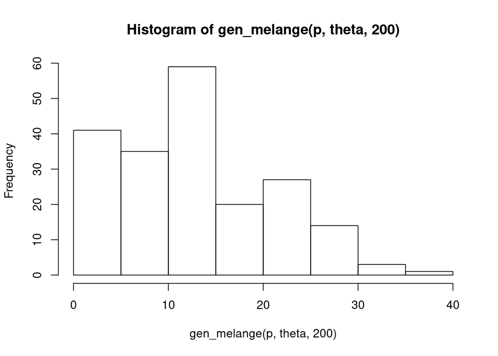

```r
K = 6
K_4 = gibbs(echantillon, K)

theta_moyen = estimation_theta(K_4$theta)
p = estimation_proportions(K_4$z, K)
theta = K_4$theta

hist_k4 = hist(gen_melange(p, theta, 200))
```

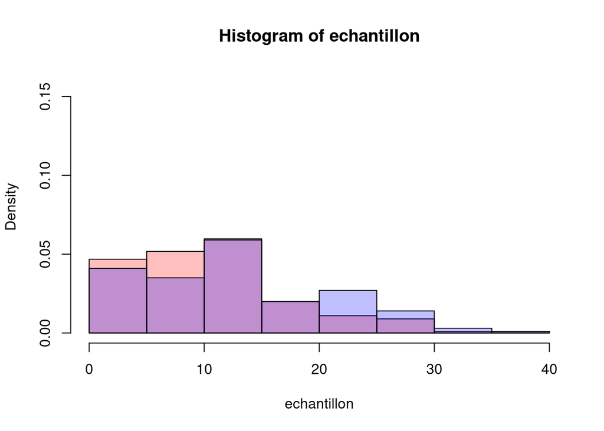

```r
plot(hist_ech, col = rgb(1,0,0,1/4), ylim = c(0,0.16), freq = FALSE)
plot(hist_k4, col = rgb(0,0,1,1/4), freq = FALSE, add = T)
```